# Are the trends in Quebec seabird abundances reflective of the Canada-wide trends?

LDP Reproducibility course - Assignment 2 Mock Manuscript

Alexandra McCallum, Valentin Lucet, Jihyun Kim, Sherry Young

## Introduction

Northern seabirds are key players in the environment and valuable bioindicators. At high latitudes, Canadian biodiversity and landscapes present a high sensitivity to climate changes (Groisman and Soja 2007). The impacts of global warming raise concerns regarding the future of Canada’s natural resources and biodiversity. Since 1970, Canadian population trends of seabirds have shown a slight increase (ECC Canada 2012). However, the warming of the ocean, the exponential increase of habitat fragmentation, the expansion of urban communities and other anthropogenic impacts (e.g. fisheries), the global deterioration of seabird environments leaves the observed national trends unexpected (Stenhouse et al. 2018). Thus, in this study, we seek to further evaluate this trend of Canadian seabird abundance and see if provincial trends are reflective of these larger scale trends. Environment and Climate Change Canada has been monitoring seabird abundance in Quebec since 1970. Therefore, Quebec serves as a good province to compare seabird abundance changes over time to Canada-wide trends. We expect to find similar trends among the seabird species at both spatial scales.

## Methods

We obtained two Canada-wide datasets for federal trends in bird abundance from the open government portal. A first dataset was concerned with the percentage change in bird abundance for different bird functional groups from 1970 to 2016 (Open Government Portal 2020b). From this dataset we produced Figure 1 by simply plotting the percentage change over time. The second dataset was concerned with characterizing species-specific trends in abundance as either stable, decreasing or increasing (Open Government Portal 2020a). This dataset is derived from an important modelling effort for a large number of bird species in Canada. We used this dataset to obtain the status of 58 different species of seabirds at the federal level.

We then accessed the Computerized Database of Québec Seabirds (ECC CDQS 2020) (CDQS), which contains monitoring data from a number of seabird colonies in Quebec. We crossed reference species names with the federal trends dataset and identified 16 matching species which represent about 28% of the species in the federal database. We only kept species for which enough data have been collected (more than 30 data points since 1970), cutting down the list of species to 14. They are listed in Table 1 and Figure 2.

The monitoring data from the CDQS is incomplete, as not all colonies have been surveyed every year (as can be seen in Figure 3). Although the CDQS contains data going back all the way to the 1800s, we filtered the dataset down to data collected from 1970, in order to allow the comparison with the federal trends. Not all colonies have been sampled starting in 1970, and not all colonies have been sampled all the way to 2016 (Figure 3). In addition, not all colonies behave similarly, with some colonies doing exceptionally well in peak years. Finally, the raw abundances reported in the CDQS cannot be compared with the trends from the federal dataset which were obtained through a modeling effort (ECC Canada 2012).

For these reasons, it was necessary to model the CDQS bird abundance in order to determine trends. Although it would have been ideal to replicate the methodology employed to determine the federal trends, It was not possible for us to do so due to time constraints. Instead, we used a very simple smoothing model on the mean abundance per year (`loess` function in R). We then calculated the difference in the predicted mean abundances for 1970 versus for 2016, from which we derived a percentage change (results of the modelling effort are shown in Figure 4). We used this value to determine the trend for Quebec seabirds (displayed in Table 1). A bird was classified as stable if the percentage change was between -15% and +15%. It was classified either as decreasing if that percentage fell below -15% and increasing if it fell above 15%. It is important to note that those percentages should not be interpreted directly as accurate predictions of change, as our simple modelling approach is likely not robust enough in that regard. Instead, they are to be used only as an indicator of the direction of change. In this sense, we believe this approach is appropriate to identify trends.

All data and code is accessible through the github repository, which is setup to replicate the computing environment used to generate the results.

## Results

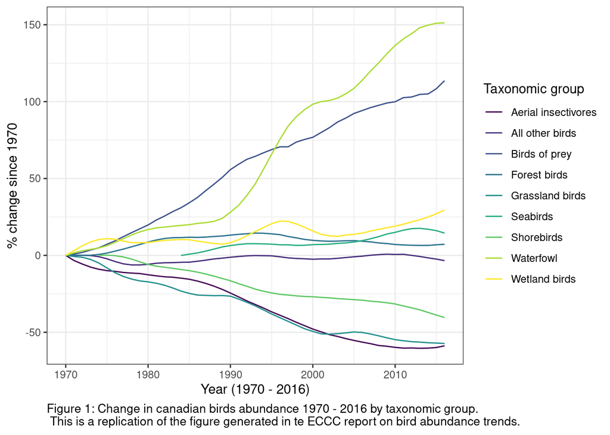

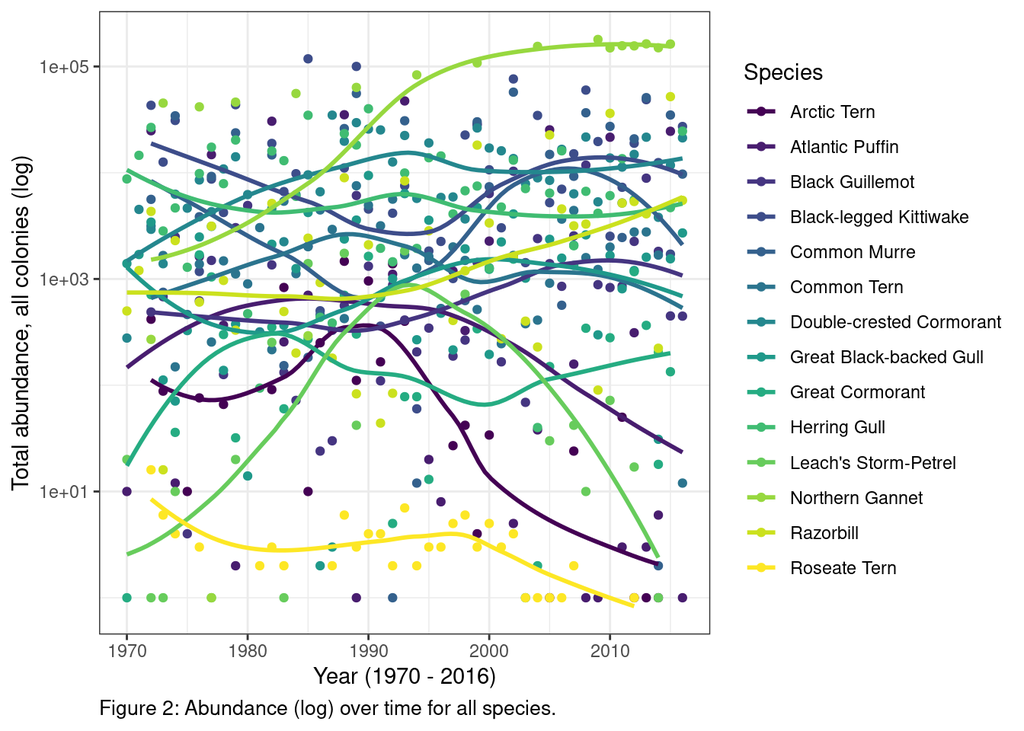

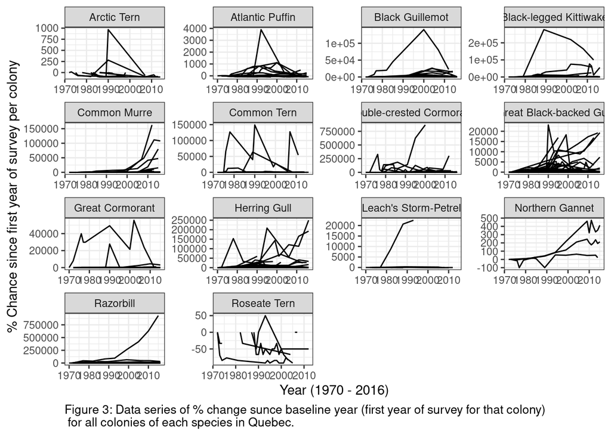

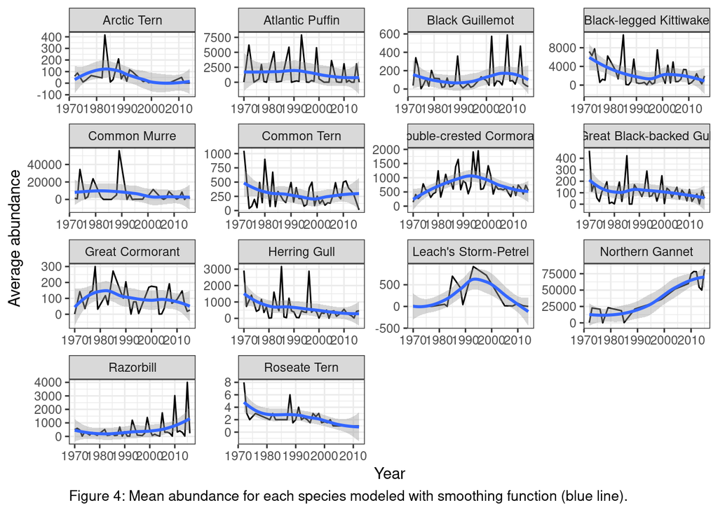

Table 1: Trends in Seabirds populations in Canada vs in Quebec

| Species | % Change in QC (1970 - 2016) | Status Canada | Status Quebec |
| --- | --- | --- | --- |
| Arctic Tern | −48.67% | Data deficient | Decreasing |
| Atlantic Puffin | −54.50% | Increasing | Decreasing |
| Black Guillemot | −35.94% | Increasing | Decreasing |
| Black-legged Kittiwake | −85.38% | Decreasing | Decreasing |
| Common Murre | −68.48% | Stable | Decreasing |
| Common Tern | −38.44% | Data deficient | Decreasing |
| Double-crested Cormorant | 115.86% | Increasing | Increasing |
| Great Black-backed Gull | −73.56% | Decreasing | Decreasing |
| Great Cormorant | 13.77% | Stable | Stable |
| Herring Gull | −81.25% | Decreasing | Decreasing |
| Leach's Storm-Petrel | −2,867.90% | Decreasing | Decreasing |
| Northern Gannet | 451.84% | Increasing | Increasing |
| Razorbill | 187.65% | Increasing | Increasing |
| Roseate Tern | −82.58% | Decreasing | Decreasing |

## Discussion

Marine seabirds are valuable bioindicators. However, they face various threats due to ocean warming, habitat fragmentation and other impacts that could drive abundance changes. Knowing the abundance trends of seabirds can help to better understand how threats are affecting these birds. In Canada, the Atlantic Puffin (Fratercula arctica), the Common Murre (Uria aalge) and the Black Guillemot (Cepphus grylle) present discrepancies in their abundance trends between the province of Quebec and Canada.

In eastern Canada, there is currently approximately 350,000 to 40,000 breeding Atlantic puffins. Most are found in Newfoundland and Labrador. (Cornell lab of Ornithology 2020b) (Nature Conservancy Canada). We found that for Canada, there is a trend showing an increase in puffin abundance. However, we find decreasing trends of abundance when looking at Quebec on a province-size scale.

The abundance of seabirds can depend on the health and availability of their food sources. As seabirds that rely heavily on food from the ocean, Atlantic puffin abundance and population health can be impacted by the presence or absence of prey fish. In turn, the prey fish availability which is affected by the primary productivity of the waters they feed in. A study by Baillie and Jones (2004) examined the impacts of the absence of capelin, a preferred food source for the Atlantic puffin, on the population’s abundance. They expected this to negatively impact on reproduction and adult survivorship in the Gannet islands, Labrador. However, they found that this change did not affect the puffin’s breeding and rearing of young as they found suitable alternative prey. Therefore, prey availability may not have affected the abundances of the puffins at either the Canada or Quebec scales.

On a national scale, the increase in both the Atlantic puffin and the Black Guillemot population abundances trends can be explained by their habitat availability. Globally, as temperatures become increasingly warmer, it can be hypothesized that the loss of sea ice may provide suitable habitats for the puffins and guillemots. This impact starting at high latitudes might contribute to the increase of abundance not seen in Quebec where new possible habitat for populations is not occurring (Wong et al. 2014). In addition, the proximity of colonies is expected to be a driver of persistence and occurrence of seabird densities.

However, a recent report linked Black Guillemot population trends to habitat loss across their Canadian range under various global warming scenarios (Audubon Field Guide 2020). It appears that habitat loss is proportional to increasing temperature across the range, with an acute habitat loss in Quebec. Black Guillemot are difficult species to record, therefore, it is difficult to evaluate other drivers that might lead to their population fluctuations. We believe that the current national trends are different from the provincial trends due to the combination of climatic and intense geographically located anthropogenic disturbances (e.g. urbanisation; habitat fragmentation/degradation), which negatively impact these specific communities in Quebec.

The Common Murre (Uria aalge) accounts for one of the most abundant seabirds of the Northern Hemisphere. The number of Common Murres seems to have risen dramatically over the past 50 years (ECC Canada 2020) with a current stable population in Canada. Their population decline in Quebec could be due to legal poaching and hunting. Common Murre are also one of the species the most frequently found as a victim of by-catch in commercial net fisheries (Smith and Morgan 2005) and found oiled on beach bird surveys (Hamel et al. 2009) along the Pacific coast (BC Breeding Bird Atlas 2020). It is thought that most of these individuals come from breeding colonies in the south closer to the Quebec region. However, currently The North American Waterbird Conservation Plan estimates a population of 4,250,000 in North America, rates the species an 11 out of 20 on the Continental Concern Score, and lists it as a Species of Moderate Concern (Cornell lab of Ornithology 2020a).

### Limitations

Differences in data collection methods may have influenced the trends and the differences we found between the Canada and Quebec abundances. However, other biological and natural causes may be affecting and causing these differences as we’ve discussed above. Another limitation to this comparison is that we do not know if Quebec data is independent of the Canada data, and if Quebec is not a random sample.

## Conclusion

Doing this comparison helps us get a clearer idea of what abundance trends are in Quebec which hadn’t been shown with the same status rating as done for Canada. Overall, the comparisons show how Canada-wide trends aren’t always reflective of smaller, province-scale trends. Changes in abundance trends can arise from changes in food source supply and quality, habitat conditions and availability, direct human impacts and other anthropogenic causes in Quebec as well as the other regions where the species are found.

## Bibliography

Audubon Field Guide. 2020. “Black Guillemot | Audubon Field Guide.” https://www.audubon.org/field-guide/bird/black-guillemot. 2020.

Baillie, Shauna M., and Ian L. Jones. 2004. “Response of Atlantic Puffins to a Decline in Capelin Abundance at the Gannet Islands, Labrador.” *Waterbirds* 27 (1): 102–11. https://doi.org/10.1675/1524-4695(2004)027[0102:ROAPTA]2.0.CO;2.

BC Breeding Bird Atlas. 2020. “BC Breeding Bird Atlas.” 2020.

Cornell lab of Ornithology. 2020a. “Common Murre Life History, All About Birds, Cornell Lab of Ornithology.” https://www.allaboutbirds.org/guide/Common_Murre/lifehistory. 2020.

———. 2020b. “NCC: Atlantic Puffin.” https://www.natureconservancy.ca/en/what-we-do/resource-centre/featured-species/birds/atlantic-puffin.html. 2020.

ECC Canada. 2012. “Trends in Canada’s Bird Populations.” Web page. https://www.canada.ca/en/environment-climate-change/services/environmental-indicators/trends-bird-populations.html. 2012.

———. 2020. “ECCC-the 21 species of the Saint-Lawrence seabirds.” OGSL. 2020.

ECC CDQS. 2020. “Computerized Database of Québec Seabirds (CDQS).” http://donnees.ec.gc.ca/data/species/ assess/computerized-database-of-qu-bec-seabirds-cdqs/. 2020.

Groisman, Pavel, and Amber Soja. 2007. “Northern Hemisphere High Latitude Climate and Environmental Change.” *Environmental Research Letters* 2 (4): 045008. https://doi.org/10.1088/1748-9326/2/4/045008.

Hamel, Nathalie J., A. E. Burger, K. Charleton, P. Davidson, S. Lee, D. F. Bertram, and J. K. Parrish. 2009. “Bycatch and Beached Birds: Assessing Mortality Impacts in Coastal Net Fisheries Using Marine Bird Strandings.” *Marine Ornithology* 37 (1): 41–60.

Open Government Portal. 2020a. “Trends in Canada’s Bird Populations Long-Term Changes in Bird Populations by Species Group, Canada - Open Government Portal.” https://open.canada.ca/data/en/dataset/766a71ce-d798-49e2-bee2-7ec65c7c5d56. 2020.

———. 2020b. “Trends in Canada’s Bird Populations Trends in Bird Populations by Species Group, Canada - Open Government Portal.” https://open.canada.ca/data/en/dataset/2d533032-3dc2-4302-b831-65e1bdcf78e7. 2020.

Smith, Joanna, and Ken H. Morgan. 2005. “An Assessment of Seabird Bycatch in Longline and Net Fisheries in British Columbia.” 401. Delta, B.C.: Canadian Wildlife Service, Pacific and Yukon Region.

Stenhouse, Iain J., Evan M. Adams, Jennifer L. Goyette, Kevin J. Regan, M. Wing Goodale, and David C. Evers. 2018. “Changes in Mercury Exposure of Marine Birds Breeding in the Gulf of Maine, 20082013.” *Marine Pollution Bulletin* 128 (March): 156–61. https://doi.org/10.1016/j.marpolbul.2018.01.025.

Wong, Sarah N. P., Carina Gjerdrum, Ken H. Morgan, and Mark L. Mallory. 2014. “Hotspots in Cold Seas: The Composition, Distribution, and Abundance of Marine Birds in the North American Arctic.” *Journal of Geophysical Research: Oceans* 119 (3): 1691–1705. https://doi.org/10.1002/2013JC009198.